# R Notebook

Plots for host and env alpha diversity models

```r
rm(list=ls())
```

```r
#install.packages("interactions")
library(jtools)
library(interactions)
library(ggplot2)
library(MuMIn)
library(lme4)
library(microbiome)
library(cowplot)
```

https://stackoverflow.com/questions/28633537/partial-residual-plot-based-on-model-average-coefficients-in-r https://stackoverflow.com/questions/25695565/predict-with-arbitrary-coefficients-in-r/25697144#25697144 https://stackoverflow.com/questions/56924967/convert-model-averaging-results-from-mumin-to-plot-in-visreg-or-effects-packages https://www.researchgate.net/post/How_can_i_plot_Estimates_of_Average_Models_using_Full_Average_values

Difficult to get plotting packages working with model averaged results. Is a hack to take the full model or one of the most complex ‘top.model’ and to replace the coefficients with those of the model.avg object?

The habitat variable is centred by the arm::standardize command and so is represented by numeric values rather than categorical factor designations. * where -0.79 is conifer and 0.21 is deciduous * maybe i could replace those values with strings before plotting? * Or just reference those values and overwrite the labels in the plot * really good blog post which deals with plotting centred predictors with interactions: https://seananderson.ca/2014/07/30/centering-interactions/

# read in data

```r
model.set.all.shannon <- readRDS("../Data/dredgeSaves/model.set.all.shannon")
model.set.all.chao <- readRDS("../Data/dredgeSaves/model.set.all.chao")

top.models <- get.models(model.set.all.shannon, subset = delta<2, REML = TRUE)
top.models2 <- get.models(model.set.all.chao, subset = delta<2, REML = TRUE)

# model.set.adult.shannon <- readRDS("../Data/dredgeSaves/model.set.adult.shannon")
# model.set.adult.chao <- readRDS("../Data/dredgeSaves/model.set.adult.chao")
#
# top.models.3 <- get.models(model.set.adult.shannon, subset = delta<2, REML = TRUE)
# top.models.4<- get.models(model.set.adult.chao, subset = delta<2, REML = TRUE)
```

```r
phylo.spring <- readRDS(file = "../Data/phylo-spring.rds")
metadata <- meta(phylo.spring) # doesnt maintain Date data-type
```

# All birds

## Distance to edge, shannon

“CUD Bright” from jtools and ultimately Paul Tol is color scheme. broodSizeXage.proteo.all[[“plot_env”]][[“colors”]] Day 8 Day 15 Adult “#49b7fc” “#ff7b00” “#17d898”

```r
#define colors for each point
#pnt.color <- ifelse(metadata$ageBinned=="adult","#17d898" , ifelse(metadata$ageBinned=="2week","#ff7b00" ,"#49b7fc"))

#scales::hue_pal(broodSizeXage.proteo.all)
```

```r
all.sh.lmm.top <- top.models[[1]]

distance.shannon.all<-effect_plot(all.sh.lmm.top,pred=z.DistanceToEdge,x.label="Distance to edge", y.label="log(Shannon)", interval =TRUE, int.type = "confidence", partial.residuals = TRUE, data = all.sh.lmm.top@frame) #point.color = pnt.color,
```

```
Confidence intervals for merMod models is an experimental feature. The intervals reflect only the variance of the fixed effects, not the
random effects.
```

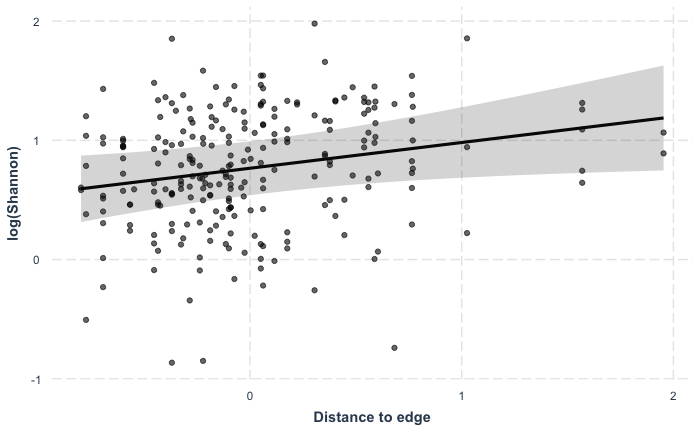

```r
distance.shannon.all
```

## Distance to edge, chao

```r
all.chao.lmm.top <- top.models2[[1]]
summary(all.chao.lmm.top)
```

```
Linear mixed model fit by REML ['lmerMod']
Formula: log(chao1) ~ ageBinned + z.DistanceToEdge + (1 | site/nest) +      (1 | SequencePlate)
   Data: metadata

REML criterion at convergence: 704.8

Scaled residuals:
     Min       1Q   Median       3Q      Max
-2.82125 -0.56340  0.04733  0.60332  2.53541

Random effects:
 Groups        Name        Variance Std.Dev.
 nest:site     (Intercept) 0.36683  0.6057
 site          (Intercept) 0.04036  0.2009
 SequencePlate (Intercept) 0.08597  0.2932
 Residual                  0.75770  0.8705
Number of obs: 246, groups:  nest:site, 61; site, 9; SequencePlate, 5

Fixed effects:
                 Estimate Std. Error t value
(Intercept)       5.61301    0.18603  30.172
ageBinned1       -0.35142    0.14602  -2.407
ageBinned2       -0.01969    0.17877  -0.110
z.DistanceToEdge  0.44887    0.19637   2.286

Correlation of Fixed Effects:
            (Intr) agBnn1 agBnn2
ageBinned1  -0.063
ageBinned2   0.092 -0.409
z.DstncTEdg -0.041  0.023 -0.025
```

```r
#all.chao.lmm.top@frame$c.habitat <- ifelse(all.chao.lmm.top@frame$c.habitat<0, "conifer", "deciduous")

distance.chao.all<-effect_plot(all.chao.lmm.top, pred=z.DistanceToEdge, x.label="Distance to edge", y.label="log(Chao)", interval =TRUE, int.type = "confidence", partial.residuals = TRUE,  data = all.chao.lmm.top@frame) #point.color = pnt.color,
```

```
Confidence intervals for merMod models is an experimental feature. The intervals reflect only the variance of the fixed effects, not the
random effects.
```

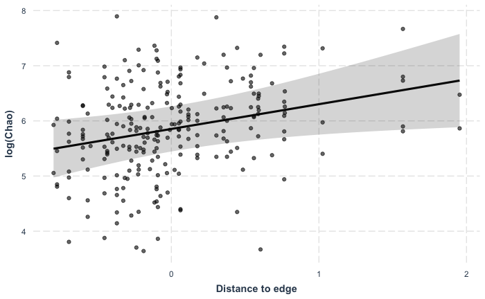

```r
distance.chao.all
```

## Age, chao

Age is significant in full averaged model while age*habitat is only included 4th top model

```r
all.chao.lmm.top <- top.models2[[1]]
summary(all.chao.lmm.top)
```

```
Linear mixed model fit by REML ['lmerMod']
Formula: log(chao1) ~ ageBinned + z.DistanceToEdge + (1 | site/nest) +      (1 | SequencePlate)
   Data: metadata

REML criterion at convergence: 704.8

Scaled residuals:
     Min       1Q   Median       3Q      Max
-2.82125 -0.56340  0.04733  0.60332  2.53541

Random effects:
 Groups        Name        Variance Std.Dev.
 nest:site     (Intercept) 0.36683  0.6057
 site          (Intercept) 0.04036  0.2009
 SequencePlate (Intercept) 0.08597  0.2932
 Residual                  0.75770  0.8705
Number of obs: 246, groups:  nest:site, 61; site, 9; SequencePlate, 5

Fixed effects:
                 Estimate Std. Error t value
(Intercept)       5.61301    0.18603  30.172
ageBinned1       -0.35142    0.14602  -2.407
ageBinned2       -0.01969    0.17877  -0.110
z.DistanceToEdge  0.44887    0.19637   2.286

Correlation of Fixed Effects:
            (Intr) agBnn1 agBnn2
ageBinned1  -0.063
ageBinned2   0.092 -0.409
z.DstncTEdg -0.041  0.023 -0.025
```

```r
#all.chao.lmm.top@frame$c.habitat <- ifelse(all.chao.lmm.top@frame$c.habitat<0, "conifer", "deciduous")

age.chao.all<-effect_plot(all.chao.lmm.top, pred=ageBinned, x.label="Age", y.label="log(Chao)", interval =TRUE, int.type = "confidence", partial.residuals = TRUE, data = all.chao.lmm.top@frame)
```

```
Confidence intervals for merMod models is an experimental feature. The intervals reflect only the variance of the
fixed effects, not the random effects.
```

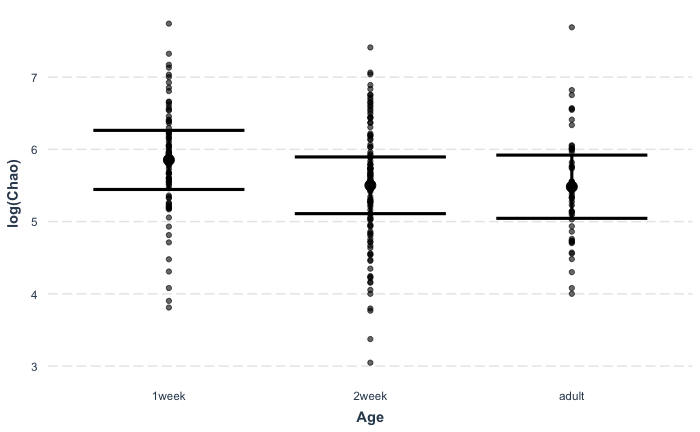

```r
age.chao.all
```

## age*habitat, chao Age is significant in full averaged model while age*habitat is only included 4th top model

[figure not shown]

# Combine plots

```r
theme_classic2 <- function(base_size = 12, base_family = ""){
  theme_bw(base_size = base_size, base_family = base_family) %+replace%
    theme(
      legend.position = "none",
      panel.border     = element_blank(),
      axis.line        = element_line(colour = "black"),
      panel.grid.major=element_line(colour="grey", size=0.5, 3),
      panel.grid.major.x = element_blank(),
      panel.grid.major.y = element_blank(),
      panel.grid.minor = element_blank(),
      panel.grid.minor.x = element_blank(),
      panel.grid.minor.y = element_blank(),
      strip.background = element_blank(),
      legend.key       = element_blank()
    )
}
```

[figure not shown]

[figure not shown]

```r
# # make grid of age plots
# p1 <- plot_grid(age.proteo.adult+theme_classic2()+ylab(NULL)+labs(title="Proteobacteria"), age.firmic.adult+theme_classic2()+ylab(NULL)+labs(title="Firmicutes"))
# p1.legend <- get_legend(age.proteo.adult)
#
# # fake legend to align properly with below plots
# p1.grid <- plot_grid(p1, p1.legend, rel_widths = c(3, .4), labels = c("A", "B", "") )
#
# #make grid of all adult interaction plots
# p2 <- plot_grid(broodSizeXsex.proteo.adult+theme_classic2()+ylab(NULL), broodSizeXsex.firmic.adult+theme_classic2()+ylab(NULL), distanceXsex.proteo.adult+theme_classic2()+ylab(NULL), distanceXsex.firmic.adult+theme_classic2()+ylab(NULL), ncol = 2, labels = c("C", "D", "E", "F"), label_x = 0, label_y = 1.1)
#
# # get common legend of all interaction plots
# p2.legend <- get_legend(broodSizeXsex.proteo.adult)
#
# p2.grid <- plot_grid(p2, p2.legend, rel_widths = c(3, .4))
#
# # combine
# adult.grid <- plot_grid(p1.grid, p2.grid, nrow = 2, rel_heights = c(1,2))
#
# adult.grid
```